# Mutyzm wybiórczy

Monika Szatkowska

10 czerwca 2018

### Co to jest mutyzm wybiórczy?

Mutyzm wybiórczy to zaburzenie lękowe.

- Dziecko lub osoba dorosła z mutyzmem wybiórczym najczęściej **swobodnie rozmawia w domu**, ale milczy lub nie rozmawia swobodnie w przedszkolu, szkole czy w innych sytuacjach społecznych.
- Zaburzenie najczęściej rozpoczyna się między drugim, a piątym rokiem życia i powinno być diagnozowane już po miesiącu milczenia w danym miejscu. Niestety często jest diagnozowane dopiero w szkole podstawowej w wieku 8-12 lat.
- Dziecko z mutyzmem wybiórczym może **w ogóle nie odzywać się do nauczycieli, rówieśników lub mówić tylko do wybranych osób.**
- Niektóre dzieci z mutyzmem wybiórczym mają problemy z jedzeniem na terenie szkoły i korzystaniem z toalety.
- Zazwyczaj nie mają trudności dydaktycznych, a często, w sytuacjach gdy mowa nie jest wymagana, mogą odnosić sukcesy szkolne.

#### W sytuacjach stresowych dzieci z mutyzmem wybiórczym często:

1. mogą mieć problem z nawiązaniem kontaktu wzrokowego
2. nie uśmiechają się, mają „kamienną twarz”, nie zdradzającą żadnych emocji
3. trudno jest im powiedzieć „cześć”, „do widzenia”, „dziękuję”
4. wydaje się, że są niekulturalne, ale nie robią tego celowo
5. czują duży niepokój, gdy są zmuszane do mówienia
6. mogą ssać palce, obgryzać paznokcie, dotykać włosy lub gryźć rękaw bluzki
7. mogą być nadwrażliwe na dotyk, zapach, dźwięki z otoczenia lub tłum ludzi
8. mają niskie poczucie własnej wartości
9. mogą być perfekcjonistami
10. nie lubią zmian, szczególnie tych które są zaskoczeniem
11. nie lubią być w centrum uwagi

### Co jest przyczyną mutyzmu wybiórczego

| Czynniki predysponujące: | Czynniki wywołujące: | Czynniki podtrzymujące: |
| --- | --- | --- |
| zaburzenia językowe, zaburzenia mowy | separacja od rodziców, utrata bliskiej osoby i inne negatywne doświadczenia dziecka np. zgubienie się w sklepie, zostawienie pod opieką innej osoby niż rodzice | negatywne wzmacnianie mutyzmu przez zwiększoną uwagę i rozczulanie się nad dzieckiem |
| lękliwość, nadwrażliwość dziecka | częste przeprowadzki i migracja | brak odpowiedniej interwencji |
| nieśmiałość lub mutyzm występujący w rodzinie | świadomość niedoskonałości mowy | rodzina należąca do mniejszości etnicznej bądź językowej |
| choroby psychiczne występujące w rodzinie, szczególnie zaburzenia lękowe | rozpoczęcie przedszkola lub szkoły | negatywny model komunikacji w rodzinie |

#### Informacje pochodzą z książki „The Selective Mutism Resource Manual”, 2001, Maggie Johnson & Alice Wintgens, którą można kupić [Tutaj](https://www.amazon.com/Selective-Mutism-Resource-Manual-Speechmark/dp/1909301337)

> Milczenie spowodowane brakiem mowy nigdy nie jest złotem. Wszyscy mamy potrzebę porozumiewania się i kontaktowania ze sobą nawzajem – nie tylko jednym sposobem, lecz na wszystkie możliwe sposoby. Jest to podstawowa ludzka potrzeba, podstawowe ludzkie prawo. Co więcej, jest to podstawowa ludzka siła (Williams, 2000)

#### Code chunks

[output not shown]

[output cut: 224 more lines]

```r
library(tidyverse)
group_by (mpg, trans) %>%
  arrange(desc(year))
```

| manufacturer | model | displ | year | cyl | trans | drv | cty | hwy | fl | class |
| --- | --- | --- | --- | --- | --- | --- | --- | --- | --- | --- |
| audi | a4 | 2.0 | 2008 | 4 | manual(m6) | f | 20 | 31 | p | compact |
| audi | a4 | 2.0 | 2008 | 4 | auto(av) | f | 21 | 30 | p | compact |
| audi | a4 | 3.1 | 2008 | 6 | auto(av) | f | 18 | 27 | p | compact |
| audi | a4 quattro | 2.0 | 2008 | 4 | manual(m6) | 4 | 20 | 28 | p | compact |
| audi | a4 quattro | 2.0 | 2008 | 4 | auto(s6) | 4 | 19 | 27 | p | compact |
| audi | a4 quattro | 3.1 | 2008 | 6 | auto(s6) | 4 | 17 | 25 | p | compact |
| audi | a4 quattro | 3.1 | 2008 | 6 | manual(m6) | 4 | 15 | 25 | p | compact |
| audi | a6 quattro | 3.1 | 2008 | 6 | auto(s6) | 4 | 17 | 25 | p | midsize |
| audi | a6 quattro | 4.2 | 2008 | 8 | auto(s6) | 4 | 16 | 23 | p | midsize |
| chevrolet | c1500 suburban 2wd | 5.3 | 2008 | 8 | auto(l4) | r | 14 | 20 | r | suv |

[output cut: 224 more lines]

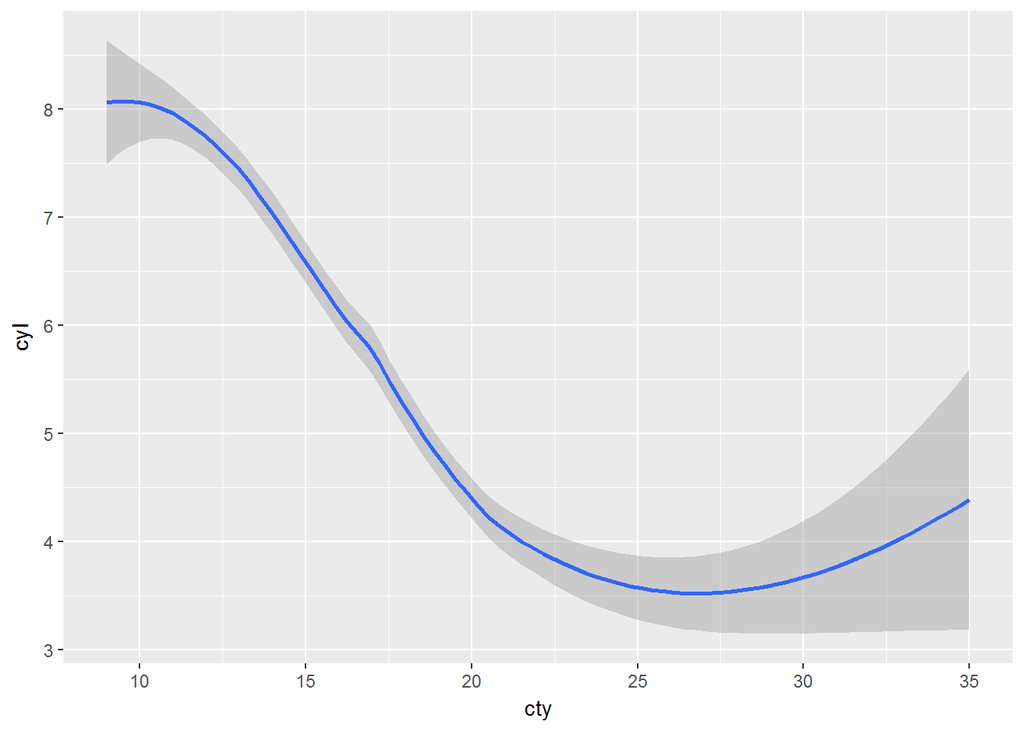

```r
library(tidyverse)
ggplot(data = mpg) +
geom_smooth(mapping = aes (x=cty, y=cyl))
```